# Sinaloas-DataViz

Wajd

15 février 2018

# LIBRAIRIES UTILISEES

On commence par récupérer toutes les librairies utilisées. Pour n’en citer que les plus importantes, tm est utilisée pour nettoyer le texte, e1071 est utilisée pour utiliser SVM, wordcloud pour dessiner des wordcloud, dplyr pour manipuler des dataframes, rweka pour tokeniser nos mots, slam pour préparer des matrices de fréquences de mots.

```r
library(stringr)
library(tm)
library(qdap)
library(e1071)
library(SnowballC)
library(wordcloud)
library(RTextTools)
library(tidytext)
library(dplyr)
library(SnowballC)
library(class)
library(wordcloud)
library(igraph)
library(RWeka)
library(slam)
```

# Fonctions personnalisées

Les trois fonctions suivantes seront utilisées par la suite pour de la tokenisation de nos mots suivant les ngram, n étant le nombre de mots successifs.

```r
BigramTokenizer <- function(x) {RWeka::NGramTokenizer(x, RWeka::Weka_control(min=2, max=2))}
ThreegramTokenizer <- function(x) {RWeka::NGramTokenizer(x, RWeka::Weka_control(min=3, max=3))}
FourgramTokenizer <- function(x) {RWeka::NGramTokenizer(x, RWeka::Weka_control(min=4, max=4))}
```

Normalize sera utilisée par la suite lors de la prédiction

```r
normalize <- function(x) {
  y <- min(x)
  z <- max(x)
  temp <- x - y
  temp1 <- (z - y)
  temp2 <- temp / temp1
  return(temp2)
}
```

Clean corpus est une méthode utilisée pour nettoyer notre corpus de documents. En somme, elle retire les caractères non latins, transforme tout le corpus en minuscule, retire les mots inutiles, et fait du word stemming.

```r
clean_corpus <- function(corpus){
  #to lower, so that we forget about uppercase
  corpus <- tm_map(corpus, content_transformer(tolower))
    #anything that doesn't fit this pattern must be eradicated
  toSpace <- content_transformer(function(x, pattern) gsub(pattern, " ", x))
  corpus <- tm_map(corpus, toSpace, "[^a-zA-Z ]")

  #remove weird letters I found
  toSpace <- content_transformer(function(x, pattern) gsub(pattern, "", x))
  corpus <- tm_map(corpus, toSpace, "â")
  toSpace <- content_transformer(function(x, pattern) gsub(pattern, "", x))
  corpus <- tm_map(corpus, toSpace, "ª")
  toSpace <- content_transformer(function(x, pattern) gsub(pattern, "", x))
  corpus <- tm_map(corpus, toSpace, "œ")
  toSpace <- content_transformer(function(x, pattern) gsub(pattern, "", x))
  corpus <- tm_map(corpus, toSpace, "¤")
  #Weird words I have never seen people use on the deep web
  weird="âœªâ¤âœªâ¤âœªâ¤âœªâ¤âœªâ¤âœªâ¤âœªâ¤âœªâ¤âœªâ¤âœªâ¤âœªâ¤âœª"
  corpus <- tm_map(corpus, stripWhitespace)
  corpus <- tm_map(corpus, removeWords, c("the","day","yes","yet", "like","œ","¤","â","will", "sale","get", "good","also","best","can",  weird,  "and", stopwords("english") ))
  corpus <- tm_map(corpus, removeNumbers)
  corpus <- tm_map(corpus, removePunctuation)

  corpus <- tm_map(corpus, stemDocument, language = "english")
  #more words I have noticed after stemming
  corpus <- tm_map(corpus, removeWords, c("onlin","ship","buy","s","rs","ab","g","com","flipkart","deliveri","cash","one","india","shop","read","set","print","new","page","come","requir","give","name","know","item","general","usd","t","red","question","add","final","take","want","see","around","discount","content","two"))
  return(corpus)
}
```

# RECUPERATION DE LA DROGUE

On récupère les données depuis deux fichiers csv prévus à l’avance, category_new et description_new, qui contiennent respectivement les catégories et les descriptions de drogues récupérées depuis le deep web.

```r
AllDrugsCategory <- read.table("Category_New.csv", header=T,fill=T, encoding="utf-8", sep="\n", dec=".",quote = "", na.string="" )
AllDrugsDescriptions <- read.table("Description_New.csv",stringsAsFactors = FALSE, header=T,fill=T, encoding="utf-8", sep="²", dec=".",quote = "", na.string="" )
```

Certaines description n’ont pas de catégories. Celles ci sont déjà naturellement à la fin du document. Il suffit de ne récupérer que les n premières, n étant le nombre de catégories

```r
AllDrugsDescriptions<-AllDrugsDescriptions[1:109690,]
AllDrugsDescriptions<-AllDrugsDescriptions$Item.Description.sep
AllDrugsCategory<-AllDrugsCategory$Category

AllDrugs<-data.frame(AllDrugsDescriptions, AllDrugsCategory)
names(AllDrugs)=c("Description", "Category")
```

Notre dataset contient tant des drogues que des armes. Nous ne nous intéresserons qu’aux drogues lors de cette étude

```r
AllDrugs=AllDrugs[which(substr(AllDrugs$Category,1,6)=="Drugs/"),]
```

Nous allons retirer également certains types de drogues très très peu représentés (1 ou deux individus)

```r
AllDrugs=AllDrugs[which(AllDrugs$Category!="Drugs/Cannabis/W"),]
AllDrugs=AllDrugs[which(AllDrugs$Category!="Drugs/Dissociatives/PCP"),]
AllDrugs=AllDrugs[which(AllDrugs$Category!="Drugs/Barbiturates"),]
AllDrugs$Category=droplevels(AllDrugs$Category)
```

On récupère exclusivement les descriptions assez longues pour maximiser notre vocabulaire. De plus, certaines descriptions, sans être vides, contiennent à peine une phrase pleine de symboles, qui disparaissent lors du nettoyage. On a opté donc pour la récupération des descriptions les plus longues de manière à avoir autant de drogues que de non-drogues dans le dataset final

```r
AllDrugs$Description=as.character(AllDrugs$Description)
AllDrugs=AllDrugs[which(nchar(AllDrugs$Description)>202),]
```

# RECUPERATION DU DATASET NON DRUGS

Flipkart est un vendeur en ligne indien aux produits variés. Le dataset ci dessous a déjà été nettoyé, récupérant uniquement les descriptions.

```r
NonDrugs <- read.table("flipkart.csv", header=T,fill=T, encoding="utf-8", sep="\n", dec=".",quote = "", na.string="" )
names(NonDrugs)=c("Description")
```

On récupère des descriptions de façon à ne garder que 20000 lignes, afin d’avoir un dataset équilibré.

```r
NonDrugs$Description=as.character(NonDrugs$Description)
NonDrugs=NonDrugs[which(nchar (NonDrugs$Description)>180),]
```

On prépare maintenant nos deux vecteurs drugs et nondrugs, contenant les descripions des produits légaux et illégaux

```r
Drugs=AllDrugs$Description
Drugs=as.character(Drugs)
NonDrugs=NonDrugs
NonDrugs=as.character(NonDrugs)
```

On crée également un vecteur legalvector et illegal vector, contenant 0 pour le vecteur illégal et 1 pour le vecteur légal. Le vecteur combiné LegalIllegal contient notre cible (target) de prédiction plus tard Le vecteur combiné Everything contient notre input pour la prédiction

```r
LegalVector<- vector(mode="numeric", length=length(NonDrugs))
IllegalVector<- vector(mode="numeric", length=length(Drugs))
IllegalVector=rep(0,19579)
LegalVector=rep(1,19962)
Everything=c(Drugs,NonDrugs)
LegalIllegal=c(IllegalVector,LegalVector)
```

MyData est le dataset qu’on utilisera pour la prédiction

```r
MyData=data.frame(Everything,LegalIllegal)
names(MyData)=c("Description", "Legality")
```

On prépare les données de MyData dans un corpus

```r
DirtyDescriptions=MyData$Description
#I need a corpus
DirtyDescriptions_source <- VectorSource(DirtyDescriptions)
DirtyDescriptions_corpus <- VCorpus(DirtyDescriptions_source)
```

On les nettoie pour ne garder que les mots les plus utiles

```r
#A clean corpus
cleandrugs_corp <- clean_corpus(DirtyDescriptions_corpus)
```

```r
#Document Term Matrix, because we need to be organized folk
cleandrug_dtm <- DocumentTermMatrix(cleandrugs_corp, control = list(weighting = weightTfIdf))
#I hate useless words
cleandrug_dtm <- removeSparseTerms(cleandrug_dtm, 0.995)
cleandrug_tdm <- TermDocumentMatrix(cleandrugs_corp, control = list(weighting = weightTfIdf))
```

Sur ce, après avoir préparé et séparé correctement nos drogues, on passe à la dataviz

# DATAVIZ DRUGS

On a séparé les datasets en drogue et non drogue. On va faire une visualisation dessus.

```r
DirtyDescriptionsDrugs_source <- VectorSource(Drugs)
DirtyDescriptionsDrugs_corpus <- VCorpus(DirtyDescriptionsDrugs_source)
#A clean corpus
cleandrugs_corp_Drugs <- clean_corpus(DirtyDescriptionsDrugs_corpus)
#Document Term Matrix, because we need to be organized folk
cleandrugdrugs_dtm <- DocumentTermMatrix(cleandrugs_corp_Drugs, control = list(weighting = weightTfIdf))
cleandrugdrugs_dtm <- removeSparseTerms(cleandrugdrugs_dtm, 0.95)
```

On aura aussi besoin d’une term document matrix, assez propre, pour faire un graphe des mots qui viennent le plus fréquemment ensemble.

```r
#I hate useless words
cleandrugdrugs_tdm <- TermDocumentMatrix(cleandrugs_corp_Drugs, control = list(weighting = weightTfIdf))
cleandrugdrugs_tdm <- removeSparseTerms(cleandrugdrugs_tdm, 0.98)
```

On commence d’abord par voir les mots les plus fréquents

```r
findFreqTerms(cleandrugdrugs_dtm, 10)
```

```
##  [1] "bud"     "cannabi" "drug"    "grade"   "gram"    "great"   "high"
##  [8] "indica"  "list"    "mdma"    "offer"   "order"   "pill"    "pleas"
## [15] "price"   "product" "profil"  "pure"    "qualiti" "sativa"  "strain"
## [22] "time"    "top"     "use"     "white"
```

```r
freq_drugs = data.frame(sort(colSums(as.matrix(cleandrugdrugs_dtm)), decreasing=TRUE))
```

et les dessiner dans un wordcloud

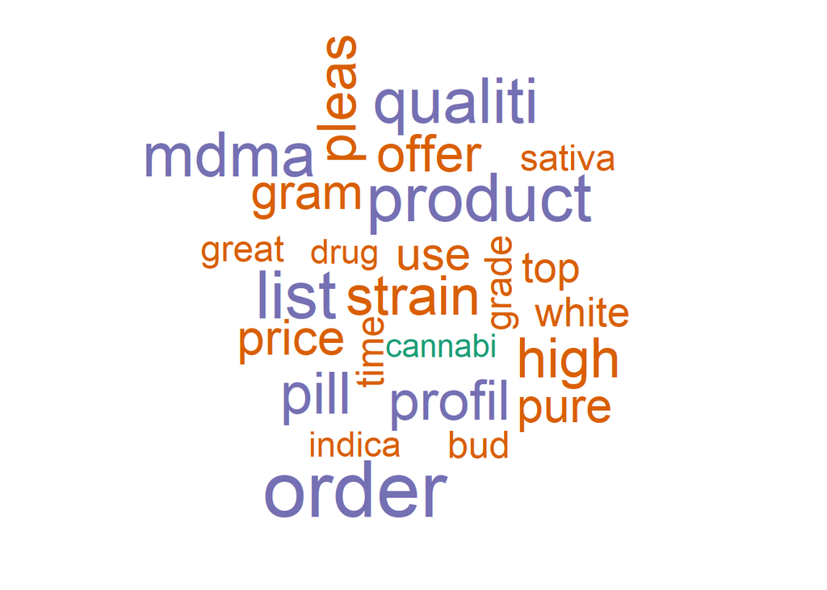

```r
wordcloud(rownames(freq_drugs), freq_drugs[,1], max.words=50, colors=brewer.pal(1, "Dark2"))
```

Ensuite, on va voir le graphe qu’on a mentionné tout à l’heure, en transformant notre tdm en matrice classique et en sélectionnant juste les mots présents

```r
vizdrugsdrugs=as.matrix(cleandrugdrugs_tdm)
vizdrugsdrugs[vizdrugsdrugs>=1] <- 1
```

on multiplier cette matrice par sa transposée pour pouvoir faire une matrice d’adjacence

```r
# transform into a term-term adjacency matrix
vizdrugsdrugs <- vizdrugsdrugs %*% t(vizdrugsdrugs)
```

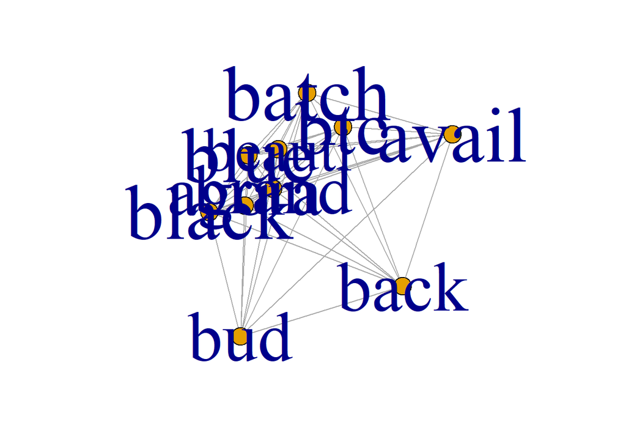

```r
# inspect terms numbered 1 to 10
somewords=vizdrugsdrugs[1:10,1:10]
# build a graph from the above matrix
g_drugs <- graph.adjacency(somewords, weighted=T, mode = "undirected")
# remove loops
g_drugs <- simplify(g_drugs)
# set labels and degrees of vertices
V(g_drugs)$label <- V(g_drugs)$name
V(g_drugs)$degree <- degree(g_drugs)
V(g_drugs)$label.cex <- 5 * V(g_drugs)$degree / max(V(g_drugs)$degree)+ .2
set.seed(3952)
layout1 <- layout.kamada.kawai(g_drugs)
plot(g_drugs, layout=layout1)
```

on va créer les document term matrix tokenisés par bigram, trigram and fourgram, pour voir les séquences de mots les plus fréquentes

```r
# creating of document matrix
options(mc.cores=1)
drugs_dtm_drugs.2g <- DocumentTermMatrix(cleandrugs_corp_Drugs, control = list(weighting = weightTfIdf, tokenize = BigramTokenizer))
options(mc.cores=1)
drugs_dtm_drugs.3g <- DocumentTermMatrix(cleandrugs_corp_Drugs, control = list(weighting = weightTfIdf, tokenize = ThreegramTokenizer))
options(mc.cores=1)
drugs_dtm_drugs.4g <- DocumentTermMatrix(cleandrugs_corp_Drugs, control = list(weighting = weightTfIdf, tokenize = FourgramTokenizer))
```

On utilise slam pour pouvoir préparer la fréquence des successions des termes qui se répètent

```r
# To get the bigram dist, we use the slam package for ops with simple triplet mat
sums_drugs.2g <- colapply_simple_triplet_matrix(drugs_dtm_drugs.2g,FUN=sum)
sums_drugs.2g <- sort(sums_drugs.2g, decreasing=T)

sums_drugs.3g <- colapply_simple_triplet_matrix(drugs_dtm_drugs.3g,FUN=sum)
sums_drugs.3g <- sort(sums_drugs.3g, decreasing=T)

sums_drugs.4g <- colapply_simple_triplet_matrix(drugs_dtm_drugs.4g,FUN=sum)
sums_drugs.4g <- sort(sums_drugs.4g, decreasing=T)
```

Fréquence bigram

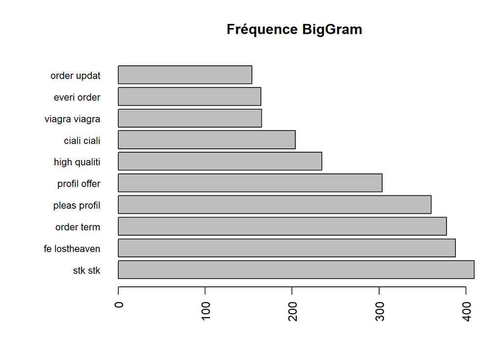

```r
par(las=2) # make label text perpendicular to axis
par(mar=c(5,8,4,2)) # increase y-axis margin.
barplot(head(sums_drugs.2g,10), main="Fréquence BigGram", horiz=TRUE,
       names.arg=head(colnames(sums_drugs.2g),10),  cex.names=0.8)
```

Fréquence trigram

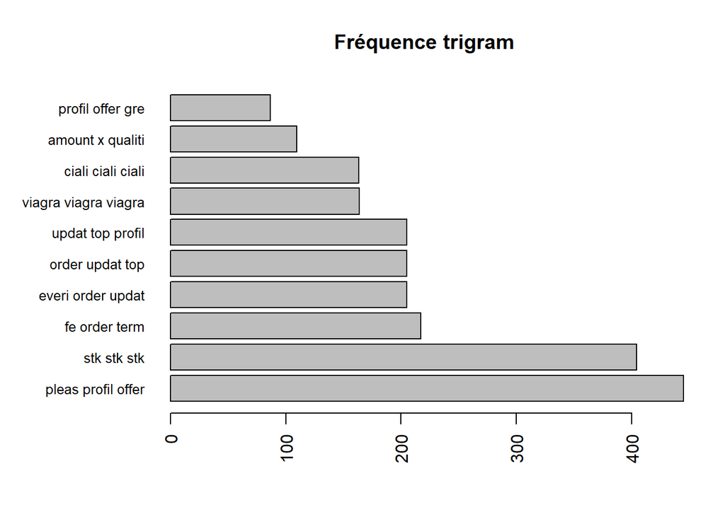

```r
par(las=2) # make label text perpendicular to axis
par(mar=c(5,8,4,2)) # increase y-axis margin.
barplot(head(sums_drugs.3g,10), main="Fréquence trigram", horiz=TRUE,
       names.arg=head(colnames(sums_drugs.3g),10),  cex.names=0.8)
```

Fréquence fourgram

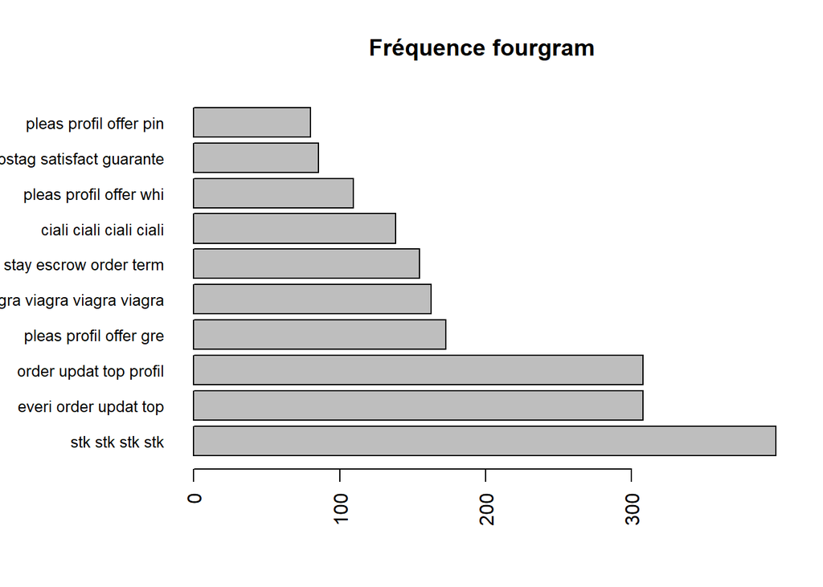

```r
par(las=2) # make label text perpendicular to axis
par(mar=c(5,8,4,2)) # increase y-axis margin.
barplot(head(sums_drugs.4g,10), main="Fréquence fourgram", horiz=TRUE,
       names.arg=head(colnames(sums_drugs.4g),10),  cex.names=0.8)
```

# DATAVIZ NON DRUGS

On passe maintenant à la visualisation des produits non drogues

On commence par la préparation du corpus, du document term matrix et term document matrix

```r
DirtyDescriptionsNonDrugs_source <- VectorSource(NonDrugs)
DirtyDescriptionsNonDrugs_corpus <- VCorpus(DirtyDescriptionsNonDrugs_source)
#A clean corpus
DirtyDescriptionsNonDrugs_corpus <- clean_corpus(DirtyDescriptionsNonDrugs_corpus)

#Document Term Matrix, because we need to be organized folk
cleandrugnondrugs_dtm <- DocumentTermMatrix(DirtyDescriptionsNonDrugs_corpus, control = list(weighting = weightTfIdf))
#I hate useless words
cleandrugnondrugs_dtm <- removeSparseTerms(cleandrugnondrugs_dtm, 0.95)
```

On prépare et nettoie la term document matrix

```r
cleandrugnondrugs_tdm <- TermDocumentMatrix(DirtyDescriptionsNonDrugs_corpus, control = list(weighting = weightTfIdf))
cleandrugnondrugs_tdm <- removeSparseTerms(cleandrugnondrugs_tdm, 0.98)
```

On commence par étudier les mots les plus fréquents

```r
findFreqTerms(cleandrugnondrugs_tdm, 10)
```

```
##   [1] "accessori"  "addit"      "alloy"      "allur"      "analog"
##   [6] "anti"       "apparel"    "art"        "artifici"   "attract"
##  [11] "auto"       "avail"      "back"       "bangl"      "beauti"
##  [16] "black"      "bleach"     "blue"       "bodi"       "box"
##  [21] "boy"        "bra"        "brand"      "brass"      "bring"
##  [26] "button"     "car"        "care"       "case"       "casual"
##  [31] "class"      "clean"      "closur"     "cloth"      "code"
##  [36] "collect"    "color"      "colour"     "combo"      "comfort"
##  [41] "compat"     "cotton"     "cover"      "coverag"    "craft"
##  [46] "custom"     "decor"      "depth"      "design"     "detail"
##  [51] "diamond"    "differ"     "dimens"     "dress"      "dri"
##  [56] "durabl"     "easi"       "eleg"       "enjoy"      "ensur"
##  [61] "exclus"     "fabric"     "fashion"    "featur"     "feel"
##  [66] "finish"     "fit"        "formal"     "free"       "front"
##  [71] "full"       "genuin"     "gift"       "girl"       "gold"
```

[output cut: 27 more lines]

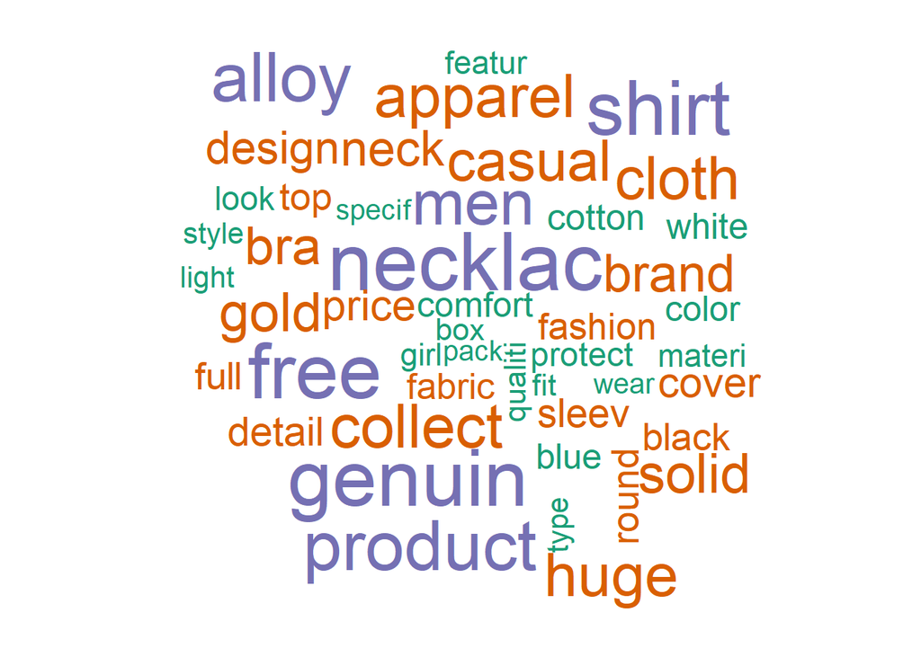

```r
freq_drugs = data.frame(sort(colSums(as.matrix(cleandrugnondrugs_dtm)), decreasing=TRUE))
wordcloud(rownames(freq_drugs), freq_drugs[,1], max.words=50, colors=brewer.pal(1, "Dark2"))
```

on passe ensuite à la visualisation des mots qui viennent ensemble. On ne prendra que les mots qui existent

```r
vizdrugsnondrugs=as.matrix(cleandrugnondrugs_tdm)
vizdrugsnondrugs[vizdrugsnondrugs>=1] <- 1
```

On multiplie la matrice par sa transposée

```r
# transform into a term-term adjacency matrix
vizdrugsnondrugs <- vizdrugsnondrugs %*% t(vizdrugsnondrugs)
```

```r
# inspect terms numbered 5 to 10
morewords=vizdrugsnondrugs[1:10,1:10]
```

On va à présent visualiser un graphe contenant les mots qui viennent ensemble

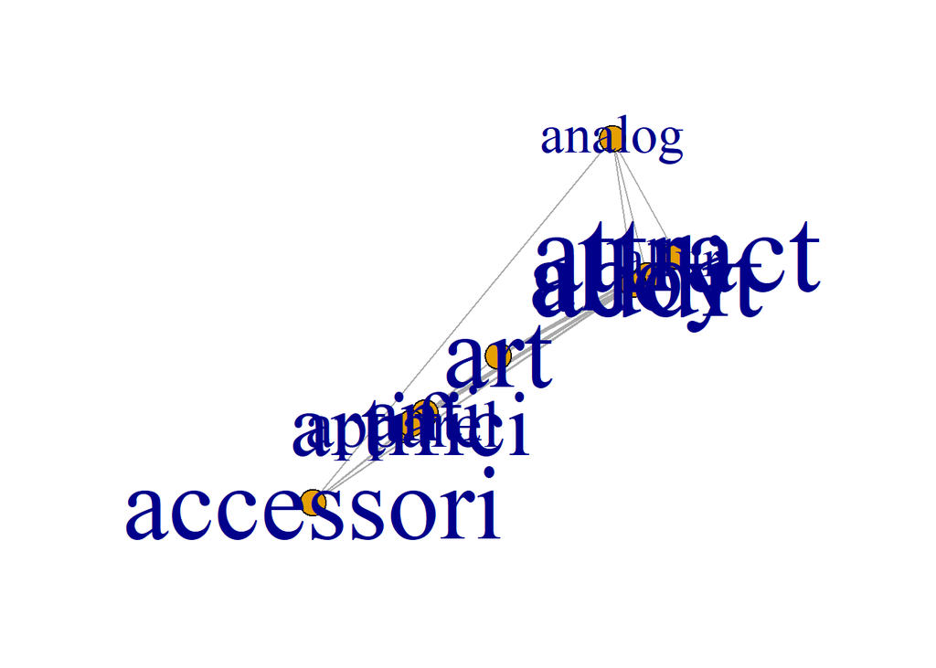

```r
# build a graph from the above matrix
g_nondrugs <- graph.adjacency(morewords, weighted=T, mode = "undirected")
# remove loops
g_nondrugs <- simplify(g_nondrugs)
# set labels and degrees of vertices
V(g_nondrugs)$label <- V(g_nondrugs)$name
V(g_nondrugs)$degree <- degree(g_nondrugs)
V(g_nondrugs)$label.cex <- 5 * V(g_nondrugs)$degree / max(V(g_nondrugs)$degree)+ .2
set.seed(3952)
layout2 <- layout.kamada.kawai(g_nondrugs)
plot(g_nondrugs, layout=layout2)
```

on va créer les document term matrix tokenisés par bigram, trigram and fourgram, pour voir les séquences de mots les plus fréquentes

```r
# creating of document matrix
options(mc.cores=1)
drugs_dtm_nondrugs.2g <- DocumentTermMatrix(DirtyDescriptionsNonDrugs_corpus, control = list(weighting = weightTfIdf, tokenize = BigramTokenizer))
options(mc.cores=1)
drugs_dtm_nondrugs.3g <- DocumentTermMatrix(DirtyDescriptionsNonDrugs_corpus, control = list(weighting = weightTfIdf, tokenize = ThreegramTokenizer))
options(mc.cores=1)
drugs_dtm_nondrugs.4g <- DocumentTermMatrix(DirtyDescriptionsNonDrugs_corpus, control = list(weighting = weightTfIdf, tokenize = FourgramTokenizer))
```

On utilise slam pour pouvoir préparer la fréquence des successions des termes qui se répètent

```r
# To get the bigram dist, we use the slam package for ops with simple triplet mat
sums_nondrugs.2g <- colapply_simple_triplet_matrix(drugs_dtm_nondrugs.2g,FUN=sum)
sums_nondrugs.2g <- sort(sums_nondrugs.2g, decreasing=T)

sums_nondrugs.3g <- colapply_simple_triplet_matrix(drugs_dtm_nondrugs.3g,FUN=sum)
sums_nondrugs.3g <- sort(sums_nondrugs.3g, decreasing=T)

sums_nondrugs.4g <- colapply_simple_triplet_matrix(drugs_dtm_nondrugs.4g,FUN=sum)
sums_nondrugs.4g <- sort(sums_nondrugs.4g, decreasing=T)
```

On fait une petite manoeuvre pour éclaircir le futur graphe

Fréquence bigram des non drogues

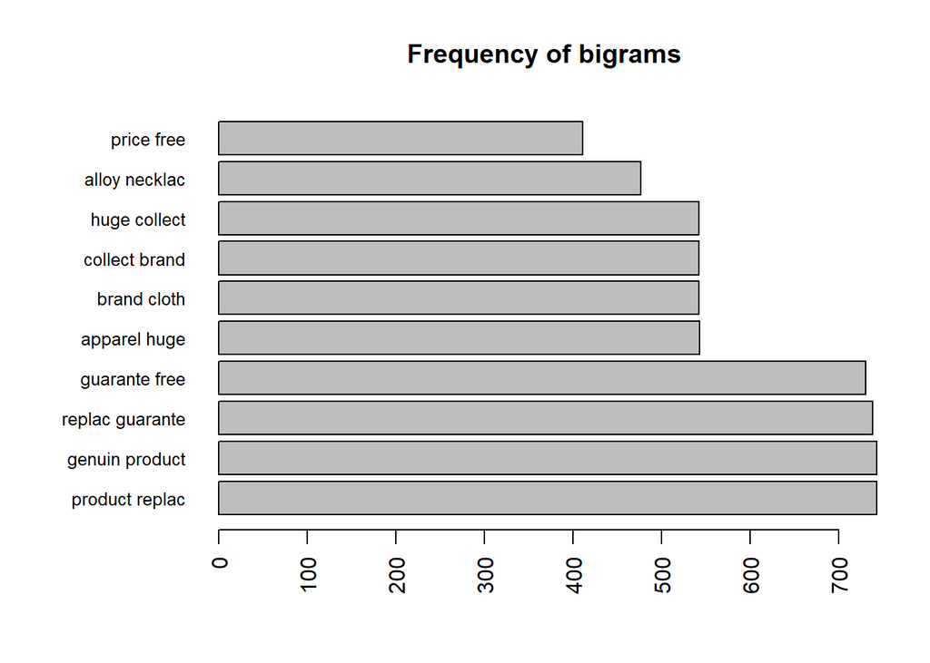

```r
par(las=2) # make label text perpendicular to axis
par(mar=c(5,8,4,2)) # increase y-axis margin.
barplot(head(sums_nondrugs.2g,10), main="Frequency of bigrams", horiz=TRUE,
        names.arg=head(colnames(sums_nondrugs.2g),10),  cex.names=0.8)
```

Fréquence trigram des non drogues

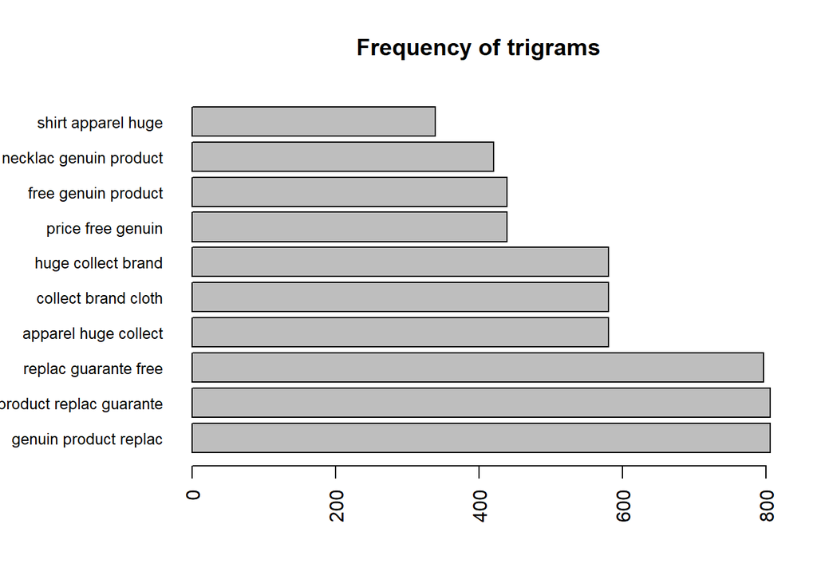

```r
par(las=2) # make label text perpenicular to axis
par(mar=c(5,8,4,2)) # increase y-axis margin.
barplot(head(sums_nondrugs.3g,10), main="Frequency of trigrams", horiz=TRUE,
        names.arg=head(colnames(sums_nondrugs.3g),10),  cex.names=0.8)
```

Fréquence fourgram des non drogues

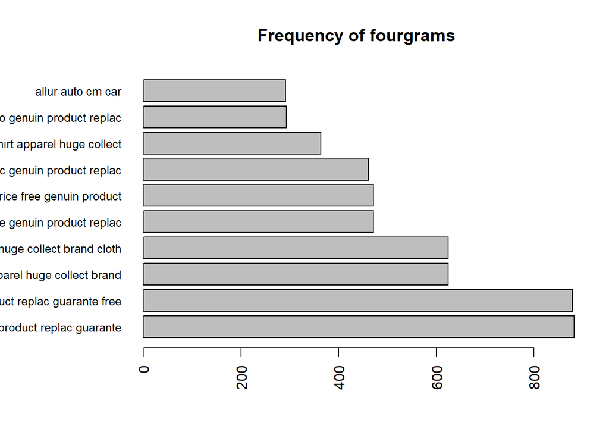

```r
par(las=2) # make label text perpendicular to axis
par(mar=c(5,8,4,2)) # increase y-axis margin.
barplot(head(sums_nondrugs.4g,10), main="Frequency of fourgrams", horiz=TRUE,
        names.arg=head(colnames(sums_nondrugs.4g),10),  cex.names=0.8)
```